# SDS/CSC 293 Mini-Project 5: LASSO

Group 15: Nashshaba Nawaz & Abby Moore

Thursday, May 2<sup>nd</sup>, 2019

You will be submiting an entry to Kaggle’s [House Prices: Advanced Regression Techniques](https://www.kaggle.com/c/house-prices-advanced-regression-techniques/) by fitting a fitted spline, multiple regression LASSO regularized multiple regression model $\hat{f}(x)$.

However of the original 1460 rows of the `training` data, in the `data/` folder you are given a `train.csv` consisting of only 50 of the rows!

# Load data

Read in data provided by Kaggle for this competition. They are organized in the `data/` folder of this RStudio project:

```r
training <- read_csv("data/train.csv") %>%
  rename(
    FirstFlrSF = `1stFlrSF`,
    SecondFlrSF = `2ndFlrSF`,
    ThirdSsnPorch = `3SsnPorch`
  ) %>%
  # Fit your models to this outcome variable:
  mutate(log_SalePrice = log(SalePrice+1))

test <- read_csv("data/test.csv")%>%
  rename(
    FirstFlrSF = `1stFlrSF`,
    SecondFlrSF = `2ndFlrSF`,
    ThirdSsnPorch = `3SsnPorch`
  )

sample_submission <- read_csv("data/sample_submission.csv")

# Function that takes in a LASSO fit object and returns a "tidy" data frame of
# the beta-hat coefficients for each lambda value used in LASSO fit.
get_LASSO_coefficients <- function(LASSO_fit){
  beta_hats <- LASSO_fit %>%
    broom::tidy(return_zeros = TRUE) %>%
    select(term, estimate, lambda) %>%
    arrange(desc(lambda))
  return(beta_hats)
}
```

## Look at your data!

Always, ALWAYS, **ALWAYS** start by looking at your raw data. This gives you visual sense of what information you have to help build your predictive models. To get a full description of each variable, read the data dictionary in the `data_description.txt` file in the `data/` folder.

Note that the following code chunk has `eval = FALSE` meaning “don’t evaluate this chunk with knitting” because `.Rmd` files won’t knit if they include a `View()`:

```r
View(training)
glimpse(training)

View(test)
glimpse(test)

# Pay close attention to the variables and variable types in sample_submission.
# Your submission must match this exactly.
glimpse(sample_submission)

# Hint:
skim(training)
skim(test)
```

## Clean-up the data

```r
# From MP2

# Combine all data for homogenous cleaning
test$SalePrice <- NA # do this so that num of cols match
test$log_SalePrice <- NA # do this so that num of cols match
combined <- rbind(training, test)

# Fix stupid stuff
combined$GarageYrBlt[combined$GarageYrBlt==2207] <- 2007

# Look for fields with lots of NAs
na_col <- which(colSums(is.na(combined)) > 0)
sort(colSums(sapply(combined[na_col], is.na)), decreasing = TRUE)
```

```
##        PoolQC     SalePrice log_SalePrice   MiscFeature         Alley
##          1506          1459          1459          1456          1400
##         Fence   FireplaceQu   LotFrontage   GarageYrBlt  GarageFinish
##          1211           753           233            80            80
##    GarageQual    GarageCond    GarageType      BsmtCond      BsmtQual
##            80            80            78            46            45
##  BsmtExposure  BsmtFinType1  BsmtFinType2    MasVnrType    MasVnrArea
##            45            43            43            16            15
##      MSZoning     Utilities  BsmtFullBath  BsmtHalfBath    Functional
##             4             2             2             2             2
##   Exterior1st   Exterior2nd    BsmtFinSF1    BsmtFinSF2     BsmtUnfSF
##             1             1             1             1             1
##   TotalBsmtSF   KitchenQual    GarageCars    GarageArea      SaleType
##             1             1             1             1             1
```

```r
# For the categorical fields where NA = meaningful, change NA to NO
combined$Alley = factor(combined$Alley, levels=c(levels(combined$Alley), "NO"))
combined$Alley[is.na(combined$Alley)] = "NO"
combined$BsmtCond = factor(combined$BsmtCond, levels=c(levels(combined$BsmtCond), "NO"))
combined$BsmtCond[is.na(combined$BsmtCond)] = "NO"
combined$BsmtExposure[is.na(combined$BsmtExposure)] = "NO"
combined$BsmtFinType1 = factor(combined$BsmtFinType1, levels=c(levels(combined$BsmtFinType1), "NO"))
combined$BsmtFinType1[is.na(combined$BsmtFinType1)] = "NO"
combined$BsmtFinType2 = factor(combined$BsmtFinType2, levels=c(levels(combined$BsmtFinType2), "NO"))
combined$BsmtFinType2[is.na(combined$BsmtFinType2)] = "NO"
combined$BsmtQual = factor(combined$BsmtQual, levels=c(levels(combined$BsmtQual), "NO"))
combined$BsmtQual[is.na(combined$BsmtQual)] = "NO"
combined$Electrical = factor(combined$Electrical, levels=c(levels(combined$Electrical), "NO"))
combined$Electrical[is.na(combined$Electrical)] = "NO" # ASSUMED
combined$FireplaceQu = factor(combined$FireplaceQu, levels=c(levels(combined$FireplaceQu), "NO"))
combined$FireplaceQu[is.na(combined$FireplaceQu)] = "NO"
combined$Fence = factor(combined$Fence, levels=c(levels(combined$Fence), "NO"))
combined$Fence[is.na(combined$Fence)] = "NO"
combined$GarageCond = factor(combined$GarageCond, levels=c(levels(combined$GarageCond), "NO"))
combined$GarageCond[is.na(combined$GarageCond)] = "NO"
combined$GarageFinish = factor(combined$GarageFinish, levels=c(levels(combined$GarageFinish), "NO"))
combined$GarageFinish[is.na(combined$GarageFinish)] = "NO"
combined$GarageQual = factor(combined$GarageQual, levels=c(levels(combined$GarageQual), "NO"))
combined$GarageQual[is.na(combined$GarageQual)] = "NO"
combined$GarageType = factor(combined$GarageType, levels=c(levels(combined$GarageType), "NO"))
combined$GarageType[is.na(combined$GarageType)] = "NO"
combined$MasVnrType = factor(combined$MasVnrType, levels=c(levels(combined$MasVnrType), "NO"))
combined$MasVnrType[is.na(combined$MasVnrType)] = "NO"
combined$MiscFeature = factor(combined$MiscFeature, levels=c(levels(combined$MiscFeature), "NO"))
combined$MiscFeature[is.na(combined$MiscFeature)] = "NO"
combined$PoolQC = factor(combined$PoolQC, levels=c(levels(combined$PoolQC), "NO"))
combined$PoolQC[is.na(combined$PoolQC)] = "NO"
combined$Utilities = factor(combined$Utilities, levels=c(levels(combined$Utilities), "NO"))
combined$Utilities[is.na(combined$Utilities)] = "NO" # ASSUMED

# For the categorical fields where NA = missing data, assume most common category
combined$Exterior1st[is.na(combined$Exterior1st)] <- names(sort(-table(combined$Exterior1st)))[1]
combined$Exterior2nd[is.na(combined$Exterior2nd)] <- names(sort(-table(combined$Exterior2nd)))[1]
combined$Functional[is.na(combined$Functional)] <- names(sort(-table(combined$Functional)))[1]
combined$KitchenQual[is.na(combined$KitchenQual)] <- names(sort(-table(combined$KitchenQual)))[1]
combined$MSZoning[is.na(combined$MSZoning)] <- names(sort(-table(combined$MSZoning)))[1]
combined$SaleType[is.na(combined$SaleType)] <- names(sort(-table(combined$SaleType)))[1]


# For the numerical fields where NA = meaningful, make NA 0
combined$BsmtFinSF1[is.na(combined$BsmtFinSF1)] <- 0
combined$BsmtFinSF2[is.na(combined$BsmtFinSF2)] <- 0
combined$BsmtFullBath[is.na(combined$BsmtFullBath)] <- 0
combined$BsmtHalfBath[is.na(combined$BsmtHalfBath)] <- 0
combined$BsmtUnfSF[is.na(combined$BsmtUnfSF)] <- 0
combined$GarageArea[is.na(combined$GarageArea)] <- 0
combined$GarageCars[is.na(combined$GarageCars)] <- 0
combined$GarageYrBlt[is.na(combined$GarageYrBlt)] <- 0
combined$LotFrontage[is.na(combined$LotFrontage)] <- 0
combined$MasVnrArea[is.na(combined$MasVnrArea)] <- 0
combined$TotalBsmtSF[is.na(combined$TotalBsmtSF)] <- 0

# Did we get rid of NAs?
na_col <- which(colSums(is.na(combined)) > 0)
sort(colSums(sapply(combined[na_col], is.na)), decreasing = TRUE)
```

```
##     SalePrice log_SalePrice
##          1459          1459
```

```r
# Separate the training and test sets again
training <- combined[1:50,]
test <- combined[51:1509,]
```

# Minimally viable product

Since we have already performed exploratory data analyses of this data in MP1 and MP2, let’s jump straight into the modeling. For this phase:

- Train an unregularized standard multiple regression model $\widehat{f}_1$ using **all** 36 numerical variables as predictors.

```r
# Train your model here:

# Model formula
model_formula <- "log_SalePrice ~ MSSubClass + LotFrontage + LotArea +
OverallQual + OverallCond + YearBuilt + YearRemodAdd + MasVnrArea + BsmtFinSF1 +
BsmtFinSF2 + BsmtUnfSF + TotalBsmtSF + FirstFlrSF + SecondFlrSF + LowQualFinSF +
GrLivArea + BsmtFullBath + BsmtHalfBath + FullBath + HalfBath + BedroomAbvGr +
KitchenAbvGr + TotRmsAbvGrd + Fireplaces + GarageYrBlt + GarageCars + GarageArea +
WoodDeckSF + OpenPorchSF + EnclosedPorch + ThirdSsnPorch + ScreenPorch + PoolArea +
MiscVal + MoSold + YrSold" %>%
  as.formula()

# Fit unregularized multiple regression model and output regression table. The
# unregularized beta-hat coefficients are in the estimate column. Recall from
# Lec18 notes that this is one "extreme". REMEMBER THESE VALUES!!!
model_1 <- lm(model_formula, data = training)

# Extract point-by-point info of points used to fit model
fitted_points_1 <- model_1 %>%
  broom::augment()

# Make predictions on test data. Compare this to use of broom::augment()
# for fitted_points()
predicted_points_1 <- model_1 %>%
  broom::augment(newdata = test)
```

# Due diligence

- Compute two RMLSE’s of the fitted model $\widehat{f}_1$
  1. on the `training` data. You may use a function from a package to achieve this.
  2. on the `test` data via a submission to Kaggle `data/submit_regression.csv`.
- Compare the two RMLSE’s. If they are different, comment on why they might be different.

```r
# Compute both RMLSE's here:
rmsle(fitted_points_1$log_SalePrice, fitted_points_1$.fitted)
```

```
## [1] 0.003618116
```

```r
# Make sample submission
sample_submission$SalePrice <- exp(predicted_points_1$.fitted) - 1 # unlog
write_csv(sample_submission, path = "data/submit_regression.csv")
```

| RMLSE on training | RMLSE on test (via Kaggle) |
| --- | --- |
| 0.003618116 | 0.21959 |

The difference in RMSLE may be due the difference in training sample size (50 vs. 1460). Because the sample size is so small, the model may be overfit to the training data, which means it won’t be robust fit outside data sets.

# Reaching for the stars

1. Find the $\lambda^*$ tuning parameter that yields the LASSO model with the lowest estimated RMLSE as well as this lowest RMLSE as well. You may use functions included in a package for this.
2. Convince yourself with a visualization that the $\lambda^*$ you found is indeed the one that returns the lowest estimated RMLSE.
3. What is the model $\widehat{f}$_2 resulting from this $\lambda^*$? Output a data frame of the $\widehat{\beta}$.
4. Visualize the progression of $\widehat{\beta}$ for different $\lambda$ values and mark $\lambda^*$ with a vertical line:

```r
# Find lambda star:

# Based on the above model formula, create "model matrix" representation of
# the predictor variables.
set.seed(76)

x_matrix <- training %>%
  modelr::model_matrix(model_formula, data = .) %>%
  select(-`(Intercept)`) %>%
  as.matrix()

# Crossvalidation:
lambda_inputs <- 10^seq(from = -5, to = 3, length = 100)

LASSO_CV <- cv.glmnet(
  x = x_matrix,
  y = training$log_SalePrice,
  alpha = 1,
  lambda = lambda_inputs,
  nfolds = 10,
  type.measure = "mse"
)

# What is te smallest estimated rmlse?
LASSO_CV_df <- LASSO_CV %>%
  broom::tidy() %>%
  rename(mse = estimate) %>%
  mutate(rmlse=sqrt(mse))%>%
  arrange(rmlse)


# The lambda_star is in the top row. We can extract this lambda_star value by getting the lambda value in the first row
lambda_star <- LASSO_CV_df$lambda[1]
lambda_star
```

```
## [1] 0.002656088
```

```r
# Lowest RMLSE value:
lowest_RMLSE <- LASSO_CV_df$rmlse[1]
lowest_RMLSE
```

```
## [1] 0.1391845
```

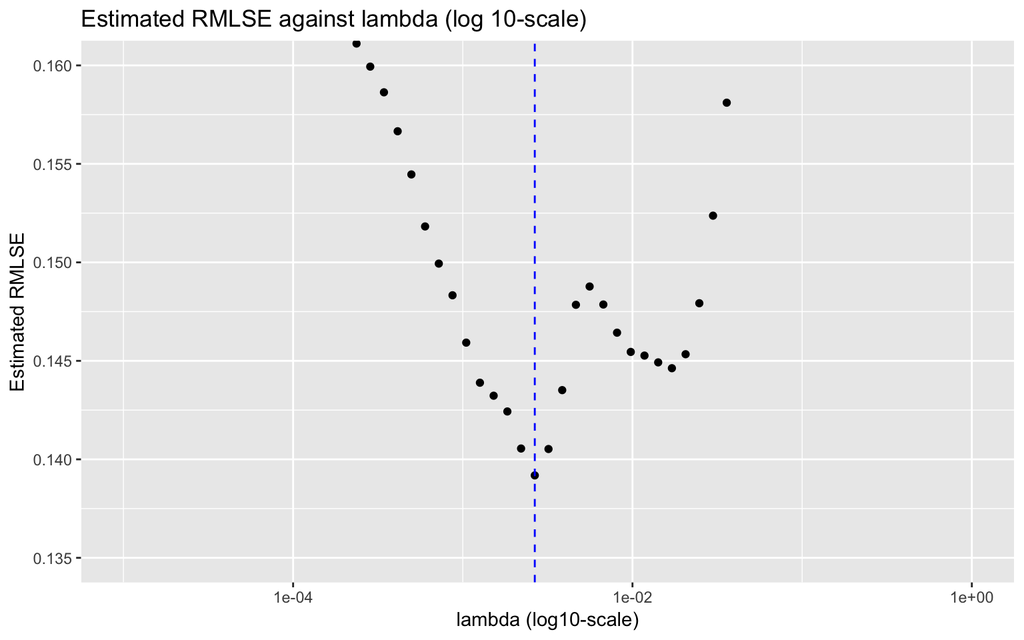

```r
# Create visualization here:
CV_plot <- LASSO_CV %>%
  broom::tidy() %>%
  rename(mse = estimate) %>%
  mutate(rmlse=sqrt(mse))%>%
  arrange(rmlse)%>%
  # plot:
  ggplot(aes(x = lambda)) +
  geom_point(aes(y = rmlse)) +
  scale_x_log10() +
  labs(x = "lambda (log10-scale)", y = "Estimated RMLSE", title = "Estimated RMLSE against lambda (log 10-scale)")

CV_plot +
  coord_cartesian(xlim=c(10^(-5), 10^0), ylim = c(0.16, 0.135)) +
  geom_vline(xintercept = lambda_star, linetype = "dashed", col = "blue")
```

```r
# Output data frame of beta-hats for the LASSO model that uses lambda_star:

# Fit a LASSO model with lambda_star
LASSO_fit_optimal <- glmnet(x = x_matrix, y = training$log_SalePrice, alpha = 1, lambda = lambda_star)

# Dataframe of beta-hats
get_LASSO_coefficients(LASSO_fit_optimal)
```

| term | estimate | lambda |
| --- | --- | --- |
| (Intercept) | 22.6369589 | 0.0026561 |
| MSSubClass | 0.0007740 | 0.0026561 |
| LotFrontage | 0.0001001 | 0.0026561 |
| LotArea | 0.0000272 | 0.0026561 |
| OverallQual | 0.1407587 | 0.0026561 |
| OverallCond | 0.0650549 | 0.0026561 |
| YearBuilt | 0.0029712 | 0.0026561 |
| YearRemodAdd | -0.0017096 | 0.0026561 |
| MasVnrArea | 0.0000000 | 0.0026561 |
| BsmtFinSF1 | 0.0000976 | 0.0026561 |
| BsmtFinSF2 | -0.0001621 | 0.0026561 |
| BsmtUnfSF | 0.0000000 | 0.0026561 |
| TotalBsmtSF | 0.0002461 | 0.0026561 |
| FirstFlrSF | 0.0000000 | 0.0026561 |
| SecondFlrSF | 0.0001391 | 0.0026561 |
| LowQualFinSF | 0.0000000 | 0.0026561 |
| GrLivArea | 0.0000190 | 0.0026561 |
| BsmtFullBath | 0.0000000 | 0.0026561 |
| BsmtHalfBath | -0.0343519 | 0.0026561 |
| FullBath | 0.0149326 | 0.0026561 |
| HalfBath | 0.0000000 | 0.0026561 |
| BedroomAbvGr | -0.0586227 | 0.0026561 |
| KitchenAbvGr | -0.2454651 | 0.0026561 |
| TotRmsAbvGrd | 0.0000000 | 0.0026561 |
| Fireplaces | 0.0051838 | 0.0026561 |
| GarageYrBlt | 0.0000498 | 0.0026561 |
| GarageCars | 0.0000000 | 0.0026561 |
| GarageArea | -0.0000581 | 0.0026561 |
| WoodDeckSF | 0.0000000 | 0.0026561 |
| OpenPorchSF | 0.0003005 | 0.0026561 |
| EnclosedPorch | -0.0000272 | 0.0026561 |
| ThirdSsnPorch | 0.0000000 | 0.0026561 |
| ScreenPorch | -0.0002455 | 0.0026561 |
| PoolArea | 0.0000000 | 0.0026561 |
| MiscVal | -0.0000699 | 0.0026561 |
| MoSold | 0.0000000 | 0.0026561 |
| YrSold | -0.0073082 | 0.0026561 |

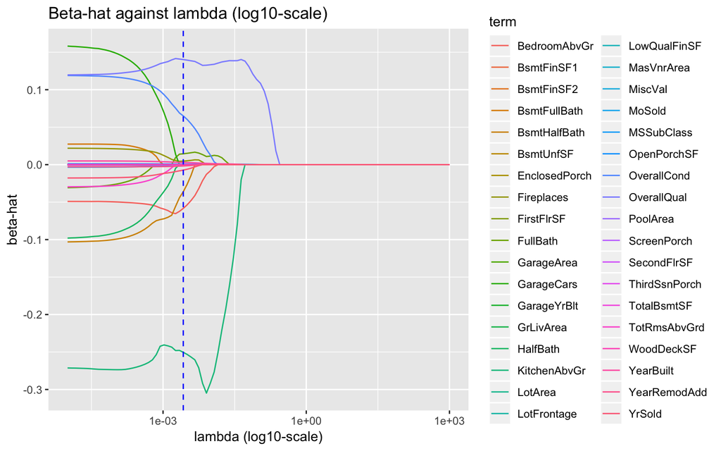

```r
# Visualize the progression of beta-hats for different lambda values and mark lambda_star with a vertical line:

# Fit LASSO model with different values of lambda
LASSO_fit_all_lambda <- glmnet(x = x_matrix, y = training$log_SalePrice, alpha = 1, lambda = lambda_inputs)

# Visualization
LASSO_coefficients_plot <- get_LASSO_coefficients(LASSO_fit_all_lambda) %>%
  filter(term != "(Intercept)") %>%
  # Plot:
  ggplot(aes(x = lambda, y = estimate, col = term)) +
  geom_line() +
  labs(x = "lambda (log10-scale)", y = "beta-hat", color="term", title="Beta-hat against lambda (log10-scale)")+
  scale_x_log10()

# 6. Now mark lambda_star in beta-hat vs lambda plot:
LASSO_coefficients_plot +
  geom_vline(xintercept = lambda_star, linetype = "dashed", col = "blue")
```

# Point of diminishing returns

1. In qualitative language, comment on the resulting amount of shrinkage in the LASSO model?
2. Obtain the RMLSE of the fitted model
   1. on the `training` data
   2. on the `test` data via a submission to Kaggle `data/submit_LASSO.csv` that we will test.
3. Compare the two RMLSE’s. If they are different, comment on why they might be different.

The LASSO model shrunk 12 variables to zero. The following table displays the variables that were not retained:

```r
my_lasso_res = get_LASSO_coefficients(LASSO_fit_optimal)
my_lasso_res = my_lasso_res[my_lasso_res$estimate==0,]
my_lasso_res[order(my_lasso_res$estimate),]
```

| term | estimate | lambda |
| --- | --- | --- |
| MasVnrArea | 0 | 0.0026561 |
| BsmtUnfSF | 0 | 0.0026561 |
| FirstFlrSF | 0 | 0.0026561 |
| LowQualFinSF | 0 | 0.0026561 |
| BsmtFullBath | 0 | 0.0026561 |
| HalfBath | 0 | 0.0026561 |
| TotRmsAbvGrd | 0 | 0.0026561 |
| GarageCars | 0 | 0.0026561 |
| WoodDeckSF | 0 | 0.0026561 |
| ThirdSsnPorch | 0 | 0.0026561 |
| PoolArea | 0 | 0.0026561 |
| MoSold | 0 | 0.0026561 |

```r
# Compute both RMLSE's here:
training <- training %>%
  mutate(y_hat_LASSO = predict(LASSO_fit_optimal, newx = x_matrix, s = lambda_star)[,1])

rmsle(training$log_SalePrice, training$y_hat_LASSO)
```

```
## [1] 0.004555799
```

```r
x_matrix_test <- test %>%
  # Create temporary outcome variance just to get model matrix to work:
  mutate(log_SalePrice = 1) %>%
  modelr::model_matrix(model_formula, data = .) %>%
  select(-`(Intercept)`) %>%
  as.matrix()

test <- test %>%
  mutate(y_hat_LASSO = predict(LASSO_fit_optimal, newx = x_matrix_test, s=lambda_star)[,1])


# Make sample submission
sample_submission$SalePrice <- exp(test$y_hat_LASSO) - 1 # unlog
write_csv(sample_submission, path = "data/submit_LASSO.csv")
```

Comparing both RMLSE’s here:

| Method | RMLSE on training | RMLSE on test (via Kaggle) |
| --- | --- | --- |
| Unregularized lm | 0.00362 | 0.219 |
| LASSO | 0.00456 | 0.193 |

Bottom line: LASSO is less specific to the training data, but is more robust for use in outside datasets. LASSO helps prevent overfitting.

# Polishing the cannonball

1. Fit a LASSO model $\widehat{f}_3$ that uses categorical variables as well.
2. Output a `data/submit_LASSO_2.csv`
3. Submit to Kaggle and replace the screenshot below with an screenshot of your score.
4. Try to get the best Kaggle leaderboard score!

```r
# Train your model here:

# Add log transform GrLivArea
training$log10_GrLivArea = log10(training$GrLivArea)
test$log10_GrLivArea = log10(test$GrLivArea) # just to run function
test$SalePrice = 1
test$log_SalePrice = 1

# Convert to factor
test$HouseStyle = as.factor(test$HouseStyle)
test$CentralAir = as.factor(test$CentralAir)

model_formula_2 <- "log_SalePrice ~ log10_GrLivArea + CentralAir + HouseStyle + MSSubClass + LotFrontage +
LotArea + OverallQual + OverallCond + YearBuilt + BsmtFinSF1 + TotalBsmtSF + SecondFlrSF + FullBath +
Fireplaces + GarageYrBlt + OpenPorchSF" %>% as.formula()

# Find lambda star:
# Based on the above model formula, create "model matrix" representation of
# the predictor variables.
x_matrix <- training %>%
  modelr::model_matrix(model_formula_2, data = .) %>%
  select(-`(Intercept)`) %>%
  as.matrix()

# Crossvalidation:
lambda_inputs <- 10^seq(from = -5, to = 3, length = 100)

LASSO_CV <- cv.glmnet(
  x = x_matrix,
  y = training$log_SalePrice,
  alpha = 1,
  lambda = lambda_inputs,
  nfolds = 10,
  type.measure = "mse"
)

# What is te smallest estimated rmlse?
LASSO_CV_df <- LASSO_CV %>%
  broom::tidy() %>%
  rename(mse = estimate) %>%
  mutate(rmlse=sqrt(mse))%>%
  arrange(rmlse)

# The lambda_star is in the top row. We can extract this lambda_star value from
# the first row of the LASSO_SV_df
lambda_star <- LASSO_CV_df$lambda[1]
lambda_star
```

```
## [1] 0.003853529
```

```r
# Fit model to training
LASSO_fit_optimal_2 <- glmnet(x = x_matrix, y = training$log_SalePrice, alpha = 1, lambda = lambda_star)

# Compute both RMLSE's here:
training <- training %>%
  mutate(y_hat_LASSO = predict(LASSO_fit_optimal_2, newx = x_matrix, s = lambda_star)[,1])
rmsle(training$log_SalePrice, training$y_hat_LASSO)
```

```
## [1] 0.00618264
```

```r
x_matrix_test <- test %>%
  # Create temporary outcome variance just to get model matrix to work:
  mutate(log_SalePrice = 1) %>%
  modelr::model_matrix(model_formula_2, data = .) %>%
  select(-`(Intercept)`) %>%
  as.matrix()

test <- test %>%
  mutate(y_hat_LASSO = predict(LASSO_fit_optimal_2, newx = x_matrix_test, s=lambda_star)[,1])
# Make sample submission
sample_submission$SalePrice <- exp(test$y_hat_LASSO) - 1 # unlog
write_csv(sample_submission, path = "data/submit_LASSO_2.csv")
```

Screenshot of Kaggle score:

[figure not shown]